# hw5

Author

jiaqi zhu

GitHub repository：https://github.com/Julie0707/506_HW5

## Problem 1 - Plotting

1. Produce a graph of the mean monthly temperature in celsius. Draw a scatter-plot where the x-axis is month and the y-axis is the average monthly temperature in celsius. Add a line connecting the points within each season and color the lines and points by season.

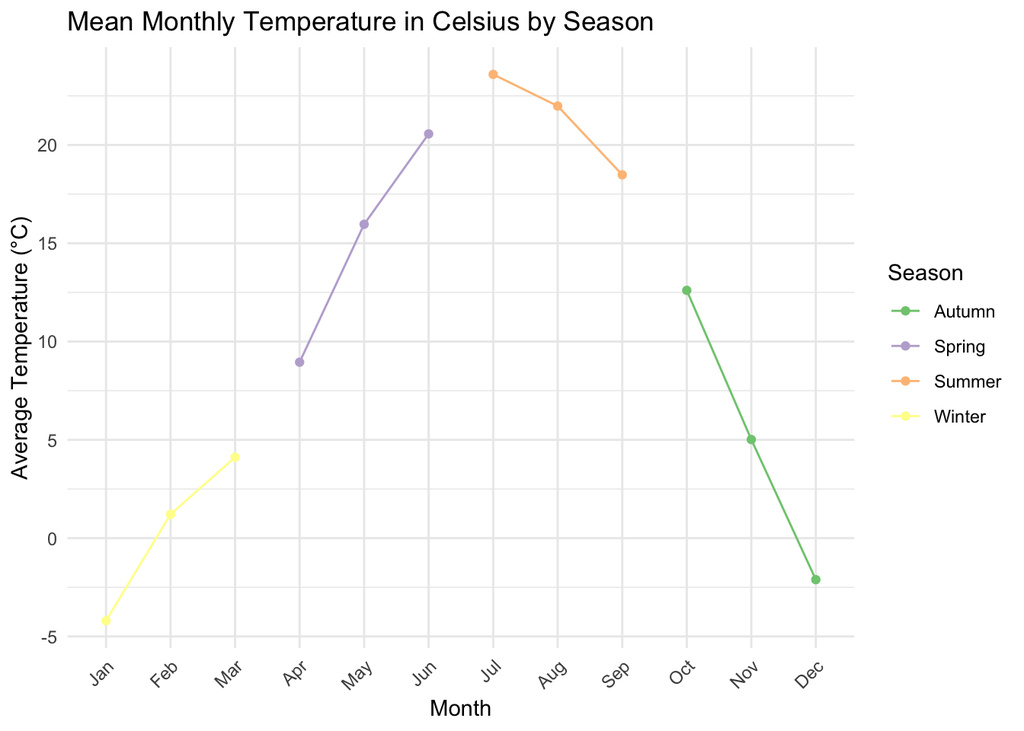

```r
library(ggplot2)
library(dplyr)
library(tidyr)

nnmaps_df <- read.csv("/Users/jiaqizhu/Downloads/chicago-nmmaps.csv")

# Convert temperature to Celsius
nnmaps_df$temp_celsius <- (nnmaps_df$temp - 32) * 5 / 9

# Ensure that 'month' is a factor and set the levels in order
nnmaps_df$month <- factor(nnmaps_df$month, levels = c("Jan", "Feb", "Mar", "Apr", "May", "Jun",
                                                      "Jul", "Aug", "Sep", "Oct", "Nov", "Dec"))

# Calculate mean monthly temperature in Celsius
monthly_avg <- nnmaps_df %>%
  group_by(month, season) %>%
  summarise(mean_temp_celsius = mean(temp_celsius, na.rm = TRUE))
# Create the scatter plot
ggplot(monthly_avg, aes(x = month, y = mean_temp_celsius, group = season, color = season)) +
  geom_point() +
  geom_line() +
  scale_color_brewer(type = "qual") +
  labs(title = "Mean Monthly Temperature in Celsius by Season",
       x = "Month",
       y = "Average Temperature (°C)",
       color = "Season") +
  theme_minimal() +
  theme(axis.text.x = element_text(angle = 45, hjust = 1))
```

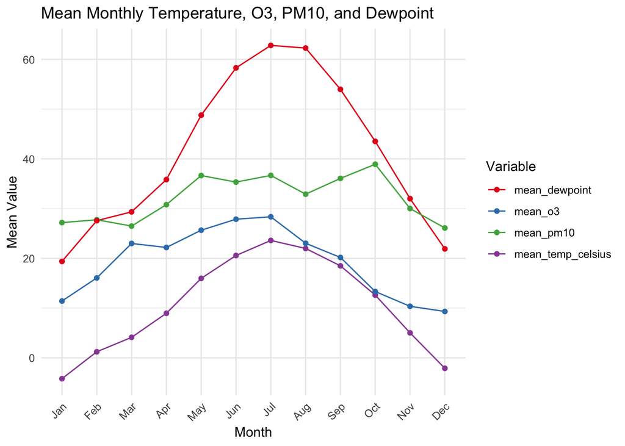

```r
# Calculate mean monthly values
monthly_avg <- nnmaps_df %>%
  group_by(month) %>%
  summarise(mean_temp_celsius = mean(temp_celsius, na.rm = TRUE),
            mean_o3 = mean(o3, na.rm = TRUE),
            mean_pm10 = mean(pm10, na.rm = TRUE),
            mean_dewpoint = mean(dewpoint, na.rm = TRUE))

monthly_avg_long <- monthly_avg %>%
  pivot_longer(cols = starts_with("mean_"), names_to = "variable", values_to = "value")

# Create the plot
ggplot(monthly_avg_long, aes(x = month, y = value, group = variable, color = variable)) +
  geom_line() +
  geom_point() +
  scale_color_brewer(palette = "Set1") +
  labs(title = "Mean Monthly Temperature, O3, PM10, and Dewpoint",
       x = "Month",
       y = "Mean Value",
       color = "Variable") +
  theme_minimal() +
  theme(axis.text.x = element_text(angle = 45, hjust = 1))
```

“Which of the four variables seems to have the least seasonal trend?”

O3 levels also exhibit some seasonal variation, though not as pronounced as temperature.

PM10 levels **fluctuate across the months**, but it’s less clear if this fluctuation follows a seasonal trend.

Based on this observation, PM10 seems to exhibit the least distinct seasonal trend compared to temperature, O3, and dewpoint. Its fluctuations across the months do not follow a clear seasonal pattern as distinctly as the temperature.

## Problem 2 - OOP Programming

```r
library(methods)

# Define the poly class
#' Poly Class
#'
#' A class to represent polynomial expressions.
#' @slot coefficients numeric Coefficients of the polynomial.
#' @slot powers numeric Powers corresponding to each coefficient in the polynomial.
setClass("poly",
         slots = c(coefficients = "numeric", powers = "numeric"))

# Constructor for the poly class
#' A constructor for the poly class.
#' @param coefficients numeric vector of coefficients.
#' @param powers numeric vector of powers.
#' @return An object of class \code{poly}.
#' @examples
#' p1 <- make_poly(c(3, 2), c(2, 0)) # 3x^2 + 2
#' p2 <- make_poly(c(7, -2, -1, 17), c(3, 2, 1, 0)) # 7x^3 - 2x^2 - x + 17
#' @export
make_poly <- function(coefficients, powers) {
  # Create a data frame for ease of manipulation
  poly_df <- data.frame(coefficients = coefficients, powers = powers)

  # Sum coefficients for like powers and sort by powers
  poly_df <- aggregate(coefficients ~ powers, data = poly_df, sum)
  poly_df <- poly_df[order(-poly_df$powers), ]

  # Create the poly object
  new("poly", coefficients = poly_df$coefficients, powers = poly_df$powers)
}

# Validator
setValidity("poly", function(object) {
  if(length(object@coefficients) != length(object@powers)) {
    return("Length of coefficients and powers should be the same")
  }
  TRUE
})
```

```
Class "poly" [in ".GlobalEnv"]

Slots:

Name:  coefficients       powers
Class:      numeric      numeric
```

```r
# Show method
#' Print Poly Object
#'
#' Method to print objects of the `poly` class.
#' @param object The `poly` object to be printed.
#' @export
setMethod("show", "poly", function(object) {
  terms <- mapply(function(coef, power) {
    term <- ""
    if (coef != 0) {
      # Determine the sign of the term
      sign <- ifelse(coef >= 0, " + ", " - ")

      abs_coef <- abs(coef)

      # Formatting the term based on its power
      if (power == 0) {  # Only display the coefficient for power 0
        term <- paste0(abs_coef)
      } else if (power == 1) {  # Display 'x' without power for power 1
        term <- paste0(abs_coef, "x")
      } else {  # Regular format for other powers
        term <- paste0(abs_coef, "x^", power)
      }

      # Prepend the sign for all terms except the first term
      if (!identical(terms, character(0))) {
        term <- paste0(sign, term)
      }
    }
    term
  }, object@coefficients, object@powers, SIMPLIFY = FALSE)

  terms <- terms[terms != ""]
  polynomial_string <- paste(terms, collapse = "")

  cat(polynomial_string, "\n")
})

# Addition method
#' Add Poly Objects
#'
#' Method to add two `poly` objects.
#' @param e1 The first `poly` object.
#' @param e2 The second `poly` object.
#' @return The sum of e1 and e2 as a new `poly` object.
#' @export
setMethod("+", c("poly", "poly"), function(e1, e2) {
  new_coefficients <- c(e1@coefficients, e2@coefficients)
  new_powers <- c(e1@powers, e2@powers)
  make_poly(new_coefficients, new_powers) # Simplification not handled
})

# Subtraction method
#' Subtract Poly Objects
#'
#' Method to subtract two `poly` objects.
#' @param e1 The first `poly` object.
#' @param e2 The second `poly` object.
#' @return The difference of e1 and e2 as a new `poly` object.
#' @export
setMethod("-", c("poly", "poly"), function(e1, e2) {
  new_coefficients <- c(e1@coefficients, -e2@coefficients)
  new_powers <- c(e1@powers, e2@powers)
  make_poly(new_coefficients, new_powers)
})

# Test the class and methods
p1 <- make_poly(c(3, 2), c(2, 0)) # 3x^2 + 2
p2 <- make_poly(c(7, -2, -1, 17), c(3, 2, 1, 0)) # 7x^3 - 2x^2 - x + 17

p1
```

```
 + 3x^2 + 2
```

```r
p2
```

```
 + 7x^3 - 2x^2 - 1x + 17
```

```r
p1 + p2
```

```
 + 7x^3 + 1x^2 - 1x + 19
```

```r
p1 - p2
```

```
 - 7x^3 + 5x^2 + 1x - 15
```

## Problem 3 - data.table

1. Generate a table reporting the mean and median departure delay per airport. Generate a second table reporting the mean and median arrival delay per airport. Exclude any destination with under 10 flights.

```r
library(nycflights13)
library(data.table)
# Convert flights data to data.table
flights_dt <- as.data.table(flights)
airports_dt <- as.data.table(airports)

# Aggregate departure delays
dep_delay_agg <- flights_dt[, .(mean_dep_delay = mean(dep_delay, na.rm = TRUE),
                                median_dep_delay = median(dep_delay, na.rm = TRUE),
                                num_flights = .N), by = .(origin)]

# Filter for airports with at least 10 flights
dep_delay_agg <- dep_delay_agg[num_flights >= 10]

# Join with airport names and order
dep_delay_table <- dep_delay_agg[airports_dt, .(airport = name, mean_dep_delay, median_dep_delay), on = .(origin = faa)]
dep_delay_table <- dep_delay_table[!is.na(mean_dep_delay) & !is.na(median_dep_delay)]
dep_delay_table <- dep_delay_table[order(-mean_dep_delay)]

# Print the departure delay table
print(dep_delay_table, nrow = nrow(dep_delay_table))
```

```
               airport mean_dep_delay median_dep_delay
1: Newark Liberty Intl       15.10795               -1
2: John F Kennedy Intl       12.11216               -1
3:          La Guardia       10.34688               -3
```

```r
# Aggregate arrival delays
arr_delay_agg <- flights_dt[, .(mean_arr_delay = mean(arr_delay, na.rm = TRUE),
                                median_arr_delay = median(arr_delay, na.rm = TRUE),
                                num_flights = .N), by = .(dest)]

# Filter for airports with at least 10 flights
arr_delay_agg <- arr_delay_agg[num_flights >= 10]

# Join with airport names and order
arr_delay_table <- arr_delay_agg[airports_dt, .(airport = name, mean_arr_delay, median_arr_delay), on = .(dest = faa)]
arr_delay_table <- arr_delay_table[!is.na(mean_arr_delay) & !is.na(median_arr_delay)]
arr_delay_table <- arr_delay_table[order(-mean_arr_delay)]

# Print the arrival delay table
print(arr_delay_table, nrow = nrow(arr_delay_table))
```

```
                                 airport mean_arr_delay median_arr_delay
 1:                Columbia Metropolitan    41.76415094             28.0
 2:                           Tulsa Intl    33.65986395             14.0
 3:                    Will Rogers World    30.61904762             16.0
 4:                 Jackson Hole Airport    28.09523810             15.0
 5:                        Mc Ghee Tyson    24.06920415              2.0
 6:               Dane Co Rgnl Truax Fld    20.19604317              1.0
 7:                        Richmond Intl    20.11125320              1.0
 8:        Akron Canton Regional Airport    19.69833729              3.0
 9:                      Des Moines Intl    19.00573614              0.0
10:                   Gerald R Ford Intl    18.18956044              1.0
11:                      Birmingham Intl    16.87732342             -2.0
12:         Theodore Francis Green State    16.23463687              1.0
13: Greenville-Spartanburg International    15.93544304             -0.5
14:    Cincinnati Northern Kentucky Intl    15.36456376             -3.0
```

[output cut: 85 more lines]

2. How many flights did the aircraft model with the fastest average speed take? Produce a tibble with 1 row, and entires for the model, average speed (in MPH) and number of flights.

```r
flights_dt <- as.data.table(flights)
planes_dt <- as.data.table(planes)

fastest_aircraft_model <- flights_dt[
  # Join with planes_dt data
  planes_dt, on = "tailnum", nomatch = 0
  ][
  # Compute time in hours and mph
  , .(time = air_time / 60, distance = distance, model = model)
  ][
  # Compute mph
  , mph := distance / time
  ][
  # Group by model and calculate average mph and number of flights
  , .(avgmph = mean(mph, na.rm = TRUE), nflights = .N), by = .(model)
  ][
  # Arrange in descending order of avgmph and get the top row
  order(-avgmph)
  ][1]

fastest_aircraft_model
```

```
     model   avgmph nflights
1: 777-222 482.6254        4
```